# Statistical Inference

EC 325: Econometrics

Prof. Caraher

Colby College

Mar 16, 2026

# From Estimates to Evidence

## Where We’ve Been

- We know how to **estimate** $\hat{\beta}_j$ using OLS
- We know the Gauss-Markov assumptions guarantee OLS is **BLUE**
- But every estimate comes from *one sample* — a different sample gives a different $\hat{\beta}_j$

**The Big Question Today**

How do we know if our estimate reflects a **real** relationship — or just **noise** from sampling?

## The Roadmap

Today we build four tools for answering that question:

1. **The sampling distribution** — what would happen across many samples?
2. **Hypothesis testing** — is there evidence of a real effect?
3. **P-values** — how strong is that evidence?
4. **Confidence intervals** — what’s the plausible range for $\beta_j$?

# The Sampling Distribution

## Why Does the Sampling Distribution Matter?

We’ve established that $\hat{\beta}_j$ varies from sample to sample — it’s a **random variable**.

If we want to say anything about whether an estimate reflects a **real** relationship or just **noise**, we need to know what the sampling distribution looks like.

**The Key Insight**

To do inference, we need to know **three things** about the sampling distribution of $\hat{\beta}_j$:

1. **Center** — where is it centered?
2. **Spread** — how much does it vary?
3. **Shape** — what distribution does it follow?

## What We Already Know

From Gauss-Markov, we’ve already established two of the three:

**1. Center: Unbiasedness**

- $E[\hat{\beta}_j] = \beta_j$ — the sampling distribution is centered on the truth

**2. Spread: The Standard Error**

- The **standard error** $se(\hat{\beta}_j)$ is the standard deviation of the sampling distribution
- It measures **how precise** our estimate is

| Scenario | Standard Error | Meaning |
| --- | --- | --- |
| Small SE | 0.02 | Estimates barely vary — very precise |
| Large SE | 2.50 | Estimates vary a lot — imprecise |

- SE depends on: sample size ($n$), variation in $x$, and noise ($\sigma^2$)
- You see the SE in the `Std. Error` column of `summary()` output

## The Missing Piece: Shape

We know the center and the spread — but that’s not enough.

Lots of distributions can have the same mean and standard deviation but look **very different**:

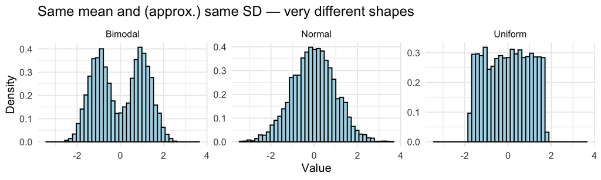

To know what’s “surprising” vs. “expected” — to do hypothesis tests and build confidence intervals — we need to know the **shape**.

## The Normality Assumption (MLR.6)

The **Classical Linear Model (CLM)** adds one assumption beyond Gauss-Markov — that the errors are **normally distributed**:

$$\mu \mid x_1, x_2, \ldots, x_k \sim Normal(0, \sigma^2)$$

What does this mean?

- Conditional on the $x$’s, the unobservable factors affecting $y$ follow a **bell curve** centered at zero
- Most observations have small errors; large errors (positive or negative) are increasingly rare

**Why This Matters**

If the errors are normal, then $\hat{\beta}_j$ — which is a linear function of the $y_i$’s — is **also normally distributed**. This gives us the shape we need.

## One Sample, One Estimate

Let’s build intuition with a simulation. Suppose the **true** model is:

$$y = 2.45 + 0 \cdot x + \mu$$

- The true effect of $x$ on $y$ is **zero** ($\beta_1 = 0$)
- But if we draw a sample and run OLS, will we get exactly zero?

```r
set.seed(42)
pop_data <- tibble(
  x = sample(1:100, size = 1000, replace = TRUE),
  y = 2.45 + 0 * x + rnorm(1000)
)

lm(y ~ x, data = pop_data) |> coef()
```

```
   (Intercept)              x
 2.48507002688 -0.00006881781
```

- Not exactly zero! We got -0.0001 — close, but not zero

## What If We Drew 1,000 Samples?

```r
set.seed(42)
n_sims <- 1000

sim_results <- map_dfr(1:n_sims, function(i) {
  sample_data <- pop_data |> slice_sample(n = 50, replace = TRUE)
  reg <- lm(y ~ x, data = sample_data)
  tibble(iteration = i, b1_hat = coef(reg)["x"])
})
```

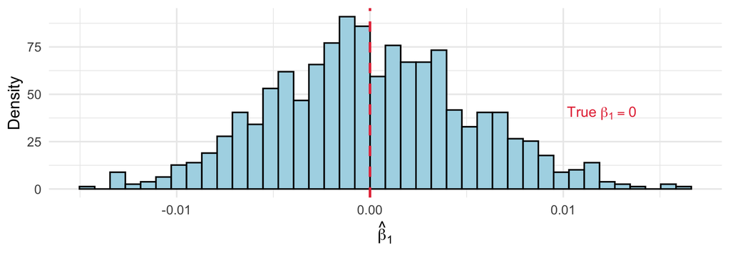

This is the **sampling distribution** — and look at its shape! It’s a **bell curve**.

## Normality of $\hat{\beta}_j$

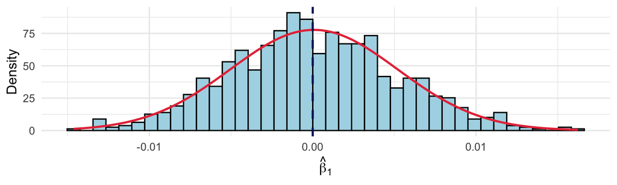

Under the **CLM assumptions** (Gauss-Markov + MLR.6):

$$\hat{\beta}_j \sim Normal\left(\beta_j, \; [se(\hat{\beta}_j)]^2\right)$$

Now we have all three pieces: center ($\beta_j$), spread ($se$), and **shape** (normal).

## But Do We Really Need Normal Errors?

Under the CLM assumptions (GM + normality of errors), $\hat{\beta}_j$ is exactly normal.

But what if errors **aren’t** normal? (Wages are skewed, health spending has a long tail…)

**The Central Limit Theorem saves us:**

$$\frac{\hat{\beta}_j - \beta_j}{se(\hat{\beta}_j)} \xrightarrow{d} Normal(0, 1) \quad \text{as } n \to \infty$$

- $\hat{\beta}_j$ is a weighted average of the $y_i$’s — and averages become normal
- Works even with non-normal errors, as long as $n$ is “large enough”

## Simulation: Normal vs. Skewed Errors

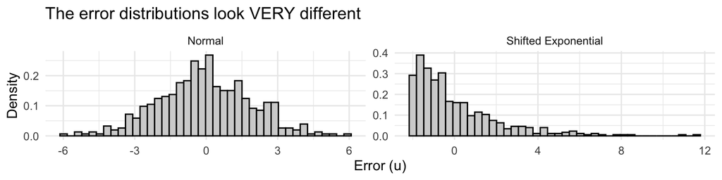

Left: symmetric bell curve. Right: heavily right-skewed (like wages).

Will $\hat{\beta}_1$ still be normally distributed with skewed errors?

## Both Sampling Distributions Are Normal!

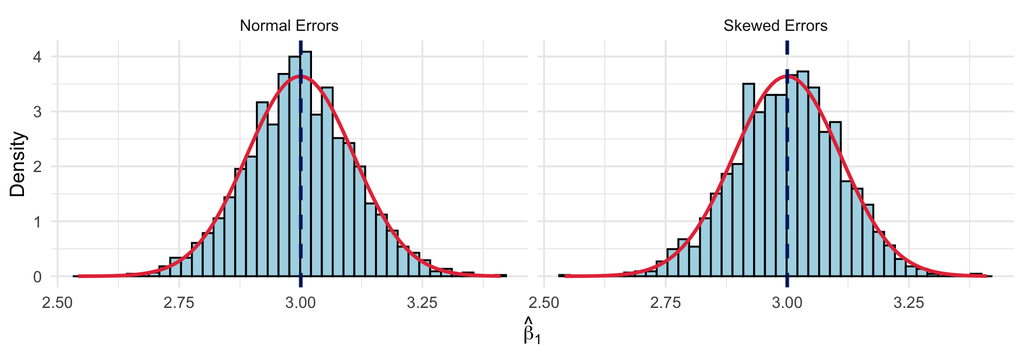

The normal curve fits **both** — even with $n = 50$ and skewed errors!

This is **asymptotic normality** at work.

# Hypothesis Testing

## The Logic of the Test

We want to know: **does $x_j$ actually affect $y$?**

We formalize this as:

- **Null hypothesis:** $H_0: \beta_j = 0$ — no effect
- **Alternative:** $H_1: \beta_j \neq 0$ — there is an effect

**The Strategy**

1. **Assume** $H_0$ is true
2. Ask: “Would my estimate be surprising under this assumption?”
3. If yes → reject $H_0$ (evidence of a real effect)

## Step 1: Under the Null, We Know What to Expect

Here’s the payoff of everything we just established. If $H_0: \beta_j = 0$ is true, then from our assumptions we know the **entire sampling distribution** of $\hat{\beta}_j$:

- **Center:** $E[\hat{\beta}_j] = 0$ (unbiasedness + the null)
- **Spread:** measured by $se(\hat{\beta}_j)$ (from the data)
- **Shape:** approximately normal (CLT / CLM assumptions)

**Putting It Together**

Under $H_0$, the sampling distribution of $\hat{\beta}_j$ is centered at zero, has a known spread, and is bell-shaped. We know **exactly** what “no effect” should look like — so we can ask whether our estimate looks like it came from that world.

## Visualizing the Null Distribution

If $\beta_j = 0$, our estimate is just **noise** — it should hover around zero:

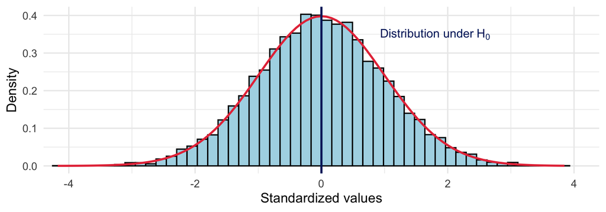

Most values cluster near zero. Values far from zero are **rare**.

**Question:** Does our estimate look like it belongs here, or is it an outlier?

## Step 2: The t-Statistic

We need to **standardize** our estimate so we can place it on that distribution:

$$t_{\hat{\beta}_j} = \frac{\hat{\beta}_j}{se(\hat{\beta}_j)}$$

- This tells us: **how many standard errors away from zero** is our estimate?

| $t$-stat | Interpretation |
| --- | --- |
| $t = 0.5$ | Half a standard error from zero — could easily be noise |
| $t = 2.0$ | Two standard errors away — unusual under $H_0$ |
| $t = 4.0$ | Four standard errors away — very unlikely to be noise |

- Same sign as $\hat{\beta}_j$ (since $se > 0$)
- Bigger $|t|$ = stronger evidence against $H_0$

## Step 3: How Far Is “Too Far”?

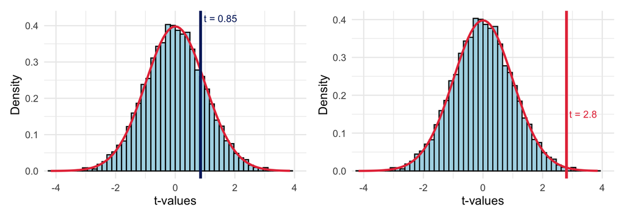

- $t = 0.85$: well within the body — no reason to doubt $H_0$
- $t = 2.8$: out in the tail — this would be **rare** if $H_0$ were true

## But We Need a Decision Rule

We can see that $t = 0.85$ feels “fine” and $t = 2.8$ feels “surprising” — but where exactly do we draw the line?

We need a **threshold** — and choosing one forces us to confront a tradeoff:

- Set the bar **too low** → we’ll reject $H_0$ too often, even when it’s true (lots of false alarms)
- Set the bar **too high** → we’ll miss real effects (too cautious)

**The Core Problem**

Even when $H_0$ is true, sampling variability means we’ll sometimes get a large $t$-stat **by chance**. We can’t eliminate this risk — but we can **control** it.

## Type I Error and the Significance Level

Rejecting $H_0$ when it’s actually true is called a **Type I error** (a “false positive”).

- The **significance level** $\alpha$ is our tolerance for this mistake
  - $\alpha = 0.05$: we accept a 5% chance of false rejection
  - $\alpha = 0.01$: we accept only a 1% chance
- The **critical value** $c$ is the threshold: reject if $|t| > c$

## Critical Values and Rejection Regions

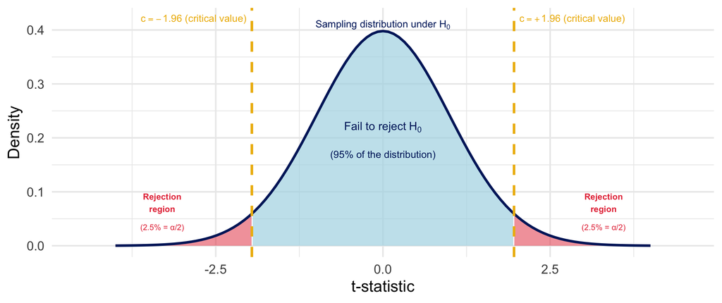

- The **red areas** combined = $\alpha = 5\%$ — the probability of a Type I error (rejecting when $H_0$ is true)
- The **dashed lines** at $\pm 1.96$ are the **critical values** — our decision boundary
- **Decision rule:** reject $H_0$ if $|t| > 1.96$

## The Rule of 2

With large samples, the critical value for a 5% test is always $\approx 1.96 \approx 2$

**Quick Rule**

An estimate is **statistically significant at 5%** if:

$$|\hat{\beta}_j| > 2 \times se(\hat{\beta}_j)$$

In other words: if the estimate is more than **twice** its standard error.

- This is a handy shortcut when scanning regression output

# P-Values

## Beyond “Reject” or “Fail to Reject”

The t-test with a fixed critical value gives a **binary** answer: significant or not.

But it doesn’t tell us **how strongly** we reject — was it a narrow rejection or a knockout?

The **p-value** answers this:

**Definition**

The p-value is the **probability of seeing a t-statistic as extreme as ours** (or more extreme), *if the null hypothesis were true*.

Equivalently: the **smallest significance level** at which we would reject $H_0$.

## Visualizing the P-Value

Think back to the rejection region plot. Instead of asking “is my t-stat past the critical value?”, the p-value asks: **how much of the distribution is more extreme than my t-stat?**

Suppose we observe $t = 2.3$. What fraction of the distribution under $H_0$ lies beyond $\pm 2.3$?

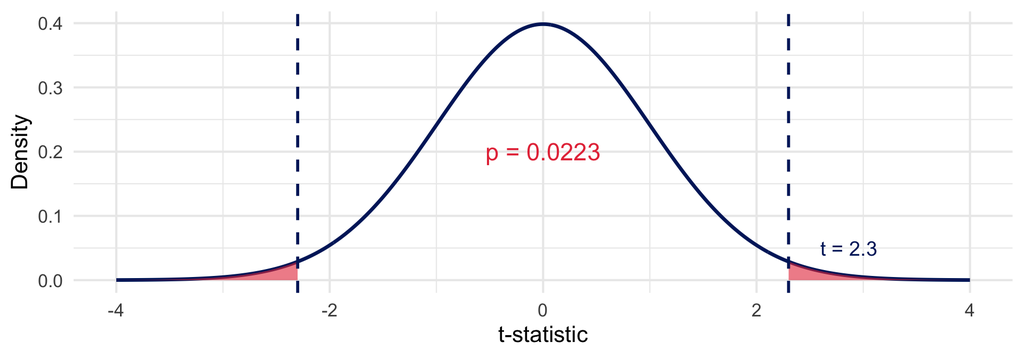

The red area = p-value = 0.0223. Only a 2.2% chance of seeing this if $H_0$ were true.

## Interpreting P-Values

- **p = 0.03:** Only a 3% chance of our estimate if $\beta_j = 0$. That’s unlikely — reject $H_0$.
- **p = 0.35:** A 35% chance of our estimate if $\beta_j = 0$. Not unusual at all — fail to reject.

**Decision rule:** Reject $H_0$ if $p < \alpha$ (your chosen significance level)

**Common Misconception**

The p-value is **NOT** the probability that $H_0$ is true!

It’s the probability of **seeing data this extreme** if $H_0$ *were* true. Big difference.

## Review: Hypothesis Testing & P-Values

**✅ Check your understanding**

You estimate $\hat{\beta}_1 = 4.5$ with $se(\hat{\beta}_1) = 2.0$.

1. What is the t-statistic?

> $t = 4.5 / 2.0 = 2.25$
2. Is this significant at the 5% level?

> Yes — $|2.25| > 1.96$
3. A colleague’s estimate has $p = 0.85$. What does that mean?

> Under $H_0$, there’s an 85% chance of seeing an estimate this extreme. Very consistent with $H_0$ — no evidence of an effect.

# Applying It All in R

## Example: Housing Prices

Now we have the full toolkit — t-statistics, p-values, and the logic connecting them. Let’s see how all of these show up in R’s regression output.

```r
set.seed(2025)
n <- 500
housing_data <- tibble(
  sqft = runif(n, 800, 3500),
  bedrooms = sample(1:5, n, replace = TRUE),
  age = sample(0:60, n, replace = TRUE),
  sale_price = 50000 + 100 * sqft + 8000 * bedrooms -
               500 * age + rnorm(n, 0, 40000)
)

# Three specifications: bivariate → add a control → full model
reg1 <- lm(sale_price ~ sqft, data = housing_data)
reg2 <- lm(sale_price ~ sqft + bedrooms, data = housing_data)
reg3 <- lm(sale_price ~ sqft + bedrooms + age, data = housing_data)
```

## Reading the Output

```r
summary(reg3)
```

```
Call:
lm(formula = sale_price ~ sqft + bedrooms + age, data = housing_data)

Residuals:
    Min      1Q  Median      3Q     Max
-113743  -30040    -224   29373  115625

Coefficients:
            Estimate Std. Error t value             Pr(>|t|)
(Intercept) 53861.26    7029.09   7.663   0.0000000000000965 ***
sqft           97.04       2.33  41.658 < 0.0000000000000002 ***
bedrooms     8667.91    1302.16   6.657   0.0000000000744502 ***
age          -514.75     103.90  -4.954   0.0000009981974212 ***
---
Signif. codes:  0 '***' 0.001 '**' 0.01 '*' 0.05 '.' 0.1 ' ' 1

Residual standard error: 41210 on 496 degrees of freedom
Multiple R-squared:  0.7837,    Adjusted R-squared:  0.7824
F-statistic: 599.1 on 3 and 496 DF,  p-value: < 0.00000000000000022
```

## Decoding `summary()`

The **Coefficients table** has four columns:

| Column | What it shows |
| --- | --- |
| `Estimate` | $\hat{\beta}_j$ — the point estimate |
| `Std. Error` | $se(\hat{\beta}_j)$ — how precise the estimate is |
| `t value` | $\hat{\beta}_j / se(\hat{\beta}_j)$ — the t-statistic |
| `Pr(>\|t\|)` | The p-value |

**Significance stars:**

| Stars | Meaning |
| --- | --- |
| (none) | $p \geq 0.10$ |
| `.` | $p < 0.10$ |
| `*` | $p < 0.05$ |
| `**` | $p < 0.01$ |
| `***` | $p < 0.001$ |

## Reading a Regression Table

In published research (and in your problem sets!), you won’t see raw `summary()` output. Instead, results are presented in a **regression table** using packages like `modelsummary`:

Table 1

|  | (1) | (2) | (3) |
| --- | --- | --- | --- |
| (Intercept) | 64627.129*** | 40665.153*** | 53861.265*** |
|  | (5699.895) | (6657.139) | (7029.089) |
| Square Feet | 96.749*** | 96.436*** | 97.043*** |
|  | (2.473) | (2.381) | (2.330) |
| Bedrooms |  | 8466.763*** | 8667.914*** |
|  |  | (1332.003) | (1302.165) |
| House Age |  |  | -514.746*** |
|  |  |  | (103.902) |
| Num.Obs. | 500 | 500 | 500 |
| R2 | 0.755 | 0.773 | 0.784 |
| R2 Adj. | 0.754 | 0.772 | 0.782 |

* p < 0.1, ** p < 0.05, *** p < 0.01  
Standard errors in parentheses. * p < 0.1, ** p < 0.05, *** p < 0.01

## Anatomy of a Regression Table

**Rows:** Each row is one regressor ($x_j$). The top number is $\hat{\beta}_j$; the number in parentheses below it is $se(\hat{\beta}_j)$.

**Columns:** Each column is a different regression specification. Here, (1) is bivariate, (2) adds bedrooms, and (3) adds house age. Placing them side-by-side lets you see how coefficients change as controls are added — this is how researchers show their results are (or aren’t) robust.

**Stars:** Indicate statistical significance — but the thresholds vary by paper! Always check the **notes at the bottom** for the convention (e.g., `* p < 0.1, ** p < 0.05, *** p < 0.01`).

**Bottom rows:** Summary statistics — typically $N$, $R^2$, adjusted $R^2$.

**Common Mistakes When Reading Tables**

- The parentheses contain **standard errors** — not t-statistics, not confidence intervals!
- Stars don’t tell you about practical significance — always look at the **magnitude** of $\hat{\beta}_j$

## Try It: Manual t-Test

**🖥️ Your turn!**

Using the full housing regression (`reg3`), compute the t-statistic for `sqft` **by hand** (using `coef()` and the standard error from `summary()`). Does it match the `t value` in the output?

```r
b1 <- coef(reg3)["sqft"]
se1 <- summary(reg3)$coefficients["sqft", "Std. Error"]
t_manual <- b1 / se1
cat("Manual t-stat:", round(t_manual, 2), "\n")
```

```
Manual t-stat: 41.66
```

```r
cat("From summary: ", round(summary(reg3)$coefficients["sqft", "t value"], 2))
```

```
From summary:  41.66
```

## Try It: P-Values in R

**🖥️ Your turn!**

Using `reg3`, compute the p-value for `sqft` by hand:

```r
# The t-stat
t_stat <- b1 / se1

# Degrees of freedom
df <- nobs(reg3) - length(coef(reg3))

# Two-sided p-value using pt()
# pt() gives P(T ≤ t). We want the probability in BOTH tails.
p_manual <- 2 * pt(abs(t_stat), df = df, lower.tail = FALSE)

cat("t-statistic:", round(t_stat, 4), "\n")
```

```
t-statistic: 41.6579
```

```r
cat("p-value:    ", format(p_manual, scientific = TRUE), "\n")
```

```
p-value:     4.381412e-164
```

# Statistical vs. Practical Significance

## Statistical vs. Practical Significance

**Key Distinction**

A **statistically significant** result ($p < 0.05$) is not necessarily **practically important**.

- With a large enough sample, even **tiny** effects become significant
- Example: A drug lowers blood pressure by 0.1 mmHg ($p = 0.001$)
  - Statistically significant? ✅
  - Clinically meaningful? ❌
- **Always** look at the **magnitude** of $\hat{\beta}_j$, not just the p-value!

# Confidence Intervals

## From Point Estimates to Ranges

A point estimate ($\hat{\beta}_j = 1.50$) gives our **best guess** — but how uncertain are we?

A **confidence interval** gives a **range of plausible values** for $\beta_j$:

$$CI = \hat{\beta}_j \pm c \cdot se(\hat{\beta}_j)$$

For a 95% CI with large $n$: $c \approx 1.96$

$$CI_{95\%} = \hat{\beta}_j \pm 1.96 \cdot se(\hat{\beta}_j)$$

## Computing CIs in R

**🖥️ Try it yourself!**

```r
# By hand
lower <- b1 - 1.96 * se1
upper <- b1 + 1.96 * se1
cat("Manual 95% CI: [", round(lower, 4), ",", round(upper, 4), "]\n")
```

```
Manual 95% CI: [ 92.4769 , 101.6087 ]
```

Or use R’s `confint()` function:

```r
# confint() computes CIs directly
# First arg = model, second = which coefficient, level = confidence level
confint(reg3, "sqft", level = 0.95)
```

```
        2.5 %   97.5 %
sqft 92.46586 101.6197
```

## What Does “95% Confident” Mean?

It does **not** mean “95% probability that $\beta_j$ is in this interval.”

The true $\beta_j$ is a fixed number — it’s either in the interval or it isn’t.

**The Correct Interpretation**

If we drew 100 different samples and computed a 95% CI from each, about **95 of them** would contain the true $\beta_j$.

Any single interval is one draw from this process — we don’t know if ours is one of the lucky 95 or the unlucky 5.

## Simulation: 50 Confidence Intervals

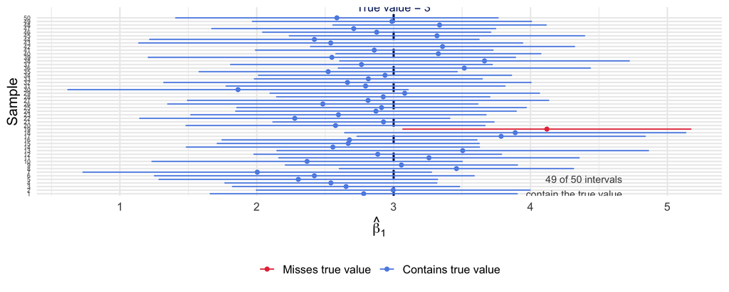

## The CI ↔︎ Hypothesis Test Connection

There’s a direct link between CIs and hypothesis testing:

| If the 95% CI… | Then at the 5% level… |
| --- | --- |
| **Excludes** zero | We **reject** $H_0: \beta_j = 0$ |
| **Includes** zero | We **fail to reject** $H_0: \beta_j = 0$ |

This makes CIs a handy visual shortcut — just check if zero is inside the interval!

**Three Tools, One Answer**

$|t| > 1.96$ ⟺ $p < 0.05$ ⟺ 95% CI excludes zero

They always agree.

## Review: Confidence Intervals

**✅ Check your understanding**

1. You estimate $\hat{\beta}_1 = 3.0$ with $se = 1.5$. What’s the 95% CI?

> $3.0 \pm 1.96 \times 1.5 = [0.06, 5.94]$
2. Does this CI suggest the effect is statistically significant at 5%?

> Yes — zero is (barely) excluded from the interval.
3. Your friend says “there’s a 95% probability that $\beta_1$ is between 0.06 and 5.94.” Is this correct?

> No! The correct interpretation is about the *procedure*, not this particular interval.

# Putting It All Together

## The Three Tools: A Comparison

| Method | Question |
| --- | --- |
| **t-statistic** | Is my estimate large relative to the noise? |
| **P-value** | How surprising would my data be if $H_0$ were true? |
| **Confidence interval** | What range of values is plausible for $\beta_j$? |

All three are mathematically connected:

- If $|t| > 1.96$, then $p < 0.05$, and the 95% CI excludes zero
- If $p < 0.05$, then $|t| > 1.96$, and the 95% CI excludes zero
- If the 95% CI excludes zero, then $p < 0.05$ and $|t| > 1.96$

## Try It: Full Inference Workflow

**🖥️ Your turn!**

Using the `mtcars` dataset, estimate `mpg ~ hp + wt`. For the coefficient on `wt`:

1. What is $\hat{\beta}_{wt}$ and its standard error?
2. Compute the t-statistic. Is it significant at 5%?
3. Compute the 95% confidence interval (by hand and using `confint()`).
4. Interpret the CI in a sentence.

```r
reg_mtcars <- lm(mpg ~ hp + wt, data = mtcars)
summary(reg_mtcars)$coefficients["wt", ]
```

```
       Estimate      Std. Error         t value        Pr(>|t|)
-3.877830742405  0.632733494377 -6.128695219810  0.000001119647
```

```r
confint(reg_mtcars, "wt", level = 0.95)
```

```
       2.5 %    97.5 %
wt -5.171916 -2.583745
```

# F-Tests: Testing Multiple Hypotheses

## The Problem with Multiple t-Tests

So far, all our tools test **one coefficient at a time**.

But what if we want to ask: “Do `bedrooms` and `age` **jointly** matter for house prices?”

You might think: just look at each t-test separately!

**Two Problems with That Approach**

1. **No restrictions on other parameters:** A t-test on $\beta_2$ puts no restrictions on $\beta_3$. Both could be individually insignificant yet *jointly* explain a lot.
2. **Multiple comparisons:** Running many tests at 5% means you’ll reject some true nulls by chance. With 20 tests, expect ~1 false rejection!

## The F-Test Solution

The **F-test** tests multiple coefficients **simultaneously**.

Consider our housing model:

$$price = \beta_0 + \beta_1(sqft) + \beta_2(bedrooms) + \beta_3(age) + \mu$$

We want to test whether `bedrooms` and `age` *jointly* matter:

$$H_0: \beta_2 = \beta_3 = 0$$
$$H_1: H_0 \text{ is not true (at least one } \neq 0 \text{)}$$

## The F-Test Compares Two Models

The key idea: compare the model **with** and **without** the restricted variables.

**Unrestricted model** (full model):
$$price = \beta_0 + \beta_1(sqft) + \beta_2(bedrooms) + \beta_3(age) + \mu$$

**Restricted model** (assuming $H_0$ is true):
$$price = \beta_0 + \beta_1(sqft) + \mu$$

If `bedrooms` and `age` actually matter, then **dropping them should make the model fit much worse.**

The F-statistic measures *how much worse* the fit gets.

## The F-Statistic Formula

$$F = \frac{(SSR_R - SSR_{UR})/q}{SSR_{UR}/df_{UR}}$$

| Symbol | Meaning |
| --- | --- |
| $SSR_R$ | Sum of squared residuals from **restricted** model |
| $SSR_{UR}$ | Sum of squared residuals from **unrestricted** model |
| $q$ | Number of restrictions (variables dropped) |
| $df_{UR}$ | Degrees of freedom in unrestricted model ($n - k - 1$) |

**Intuition:** The numerator captures how much the fit worsens when we drop the variables. The denominator scales by the noise in the data. A large $F$ means the dropped variables really mattered.

## How Big Is “Big Enough”? The F Distribution

We have an F-statistic — but how do we know if it’s large enough to reject $H_0$?

Same logic as the t-test: we need a **reference distribution** that tells us what $F$ values we’d expect to see *if the null were true*.

Under $H_0$ (the dropped variables truly don’t matter), the F-statistic follows the **F distribution** with parameters $q$ (numerator df) and $df_{UR}$ (denominator df).

- The F distribution is **right-skewed** and always **non-negative** (since SSR can only *increase* when we drop variables, $F \geq 0$)
- Under $H_0$, the F-stat should be close to **1** on average (dropping irrelevant variables barely worsens fit)
- If $F$ is **much larger than 1**, it’s unlikely under $H_0$ — evidence that the dropped variables matter

**Decision Rule**

Choose a significance level $\alpha$ (typically 5%). Find the **critical value** $F_{crit}$ such that $P(F > F_{crit}) = \alpha$. If our F-statistic exceeds $F_{crit}$, **reject $H_0$**.

## F-Test: Computing It by Hand

- I can use the `qf()` function to find $F_{crit}$

```r
# Unrestricted model (full model)
reg_unrestricted <- lm(sale_price ~ sqft + bedrooms + age,
                       data = housing_data)

# Restricted model (drop bedrooms and age)
reg_restricted <- lm(sale_price ~ sqft, data = housing_data)

# Compute F-statistic manually
ssr_r <- sum(resid(reg_restricted)^2)
ssr_ur <- sum(resid(reg_unrestricted)^2)
df_ur <- df.residual(reg_unrestricted)
q <- 2  # number of restrictions

f_stat <- ((ssr_r - ssr_ur) / q) / (ssr_ur / df_ur)

# Critical value at 5% significance
f_crit <- qf(0.05, df1 = q, df2 = df_ur, lower.tail = FALSE)

cat("F-statistic:", round(f_stat, 2), "\n")
```

```
F-statistic: 33.43
```

```r
cat("Critical value (5%):", round(f_crit, 2), "\n")
```

```
Critical value (5%): 3.01
```

```r
cat("Reject H0?", f_stat > f_crit, "\n")
```

```
Reject H0? TRUE
```

## Visualizing the F Distribution

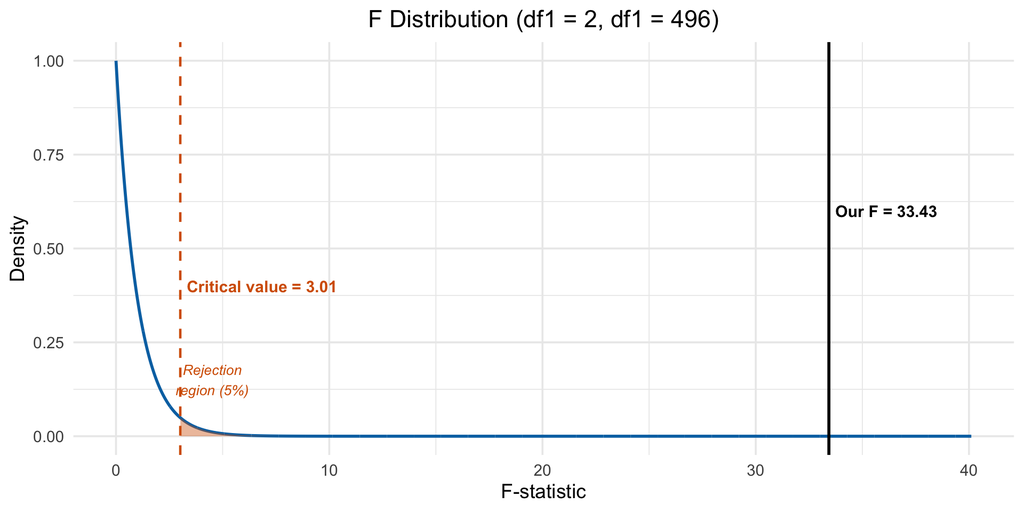

Our F-statistic falls **deep in the rejection region** — strong evidence that `bedrooms` and `age` jointly matter.

## The Easy Way: `anova()`

In practice, use R’s `anova()` function — pass it the restricted model first, then the unrestricted:

```r
anova(reg_restricted, reg_unrestricted)
```

```
Analysis of Variance Table

Model 1: sale_price ~ sqft
Model 2: sale_price ~ sqft + bedrooms + age
  Res.Df          RSS Df    Sum of Sq      F              Pr(>F)
1    498 955884067193
2    496 842335853904  2 113548213289 33.431 0.00000000000002398 ***
---
Signif. codes:  0 '***' 0.001 '**' 0.01 '*' 0.05 '.' 0.1 ' ' 1
```

It gives you the F-statistic, degrees of freedom, and p-value directly.

## The F-Statistic in Terms of $R^2$

The F-statistic can also be written using R-squared values:

$$F = \frac{(R^2_{UR} - R^2_R)/q}{(1 - R^2_{UR})/df_{UR}}$$

This version makes the intuition even clearer:

- **Numerator:** How much does $R^2$ *improve* when we add the extra variables?
- **Denominator:** How much unexplained variation remains in the full model?

```r
r2_r <- summary(reg_restricted)$r.squared
r2_ur <- summary(reg_unrestricted)$r.squared

f_r2 <- ((r2_ur - r2_r) / q) / ((1 - r2_ur) / df_ur)
cat("F from SSR formula:", round(f_stat, 2), "\n")
```

```
F from SSR formula: 33.43
```

```r
cat("F from R² formula: ", round(f_r2, 2), "\n")
```

```
F from R² formula:  33.43
```

Same answer — just two ways to compute the same thing.

## Properties of the F-Test

**Key Properties**

- The F-statistic is **always non-negative**, so F-tests are always **one-sided** (we only reject in the right tail)
- If we reject $H_0$, we say the variables are **jointly statistically significant**
- We **cannot** determine *which* individual variable is significant — only that at least one matters
- If variables are jointly insignificant, it provides justification for **dropping them** from the model

## Try It: F-Test Workflow

**🖥️ Your turn!**

Using the `housing_data`, test whether `bedrooms` and `age` jointly matter by:

1. Estimate the unrestricted model: `sale_price ~ sqft + bedrooms + age`
2. Estimate the restricted model: `sale_price ~ sqft`
3. Use `anova()` to perform the F-test
4. What is the F-statistic? Do you reject $H_0$ at 5%?

```r
anova(
    lm(sale_price ~ sqft, data = housing_data),
    lm(sale_price ~ sqft + bedrooms + age, data = housing_data)
)
```

```
Analysis of Variance Table

Model 1: sale_price ~ sqft
Model 2: sale_price ~ sqft + bedrooms + age
  Res.Df          RSS Df    Sum of Sq      F              Pr(>F)
1    498 955884067193
2    496 842335853904  2 113548213289 33.431 0.00000000000002398 ***
---
Signif. codes:  0 '***' 0.001 '**' 0.01 '*' 0.05 '.' 0.1 ' ' 1
```

# Wrapping Up

## Key Takeaways

**What You Should Remember**

1. **Sampling distribution:** $\hat{\beta}_j$ varies across samples; the SE measures how much
2. **Hypothesis test:** Compare your t-stat to 1.96 (or use the Rule of 2)
3. **P-value:** The probability of your data under $H_0$ — small $p$ = strong evidence against $H_0$
4. **Confidence interval:** A range of plausible values for $\beta_j$
5. **F-test:** Tests whether multiple coefficients are *jointly* significant — use `anova()` in R
6. **Statistical ≠ practical significance** — always look at the *magnitude*, not just the stars!

EC325 | Unit 6 | Statistical Inference